# Session 16: Hypothesis testing

This work is licensed under a [Creative Commons Attribution-ShareAlike 4.0 International License](http://creativecommons.org/licenses/by-sa/4.0/).

Load the libraries.

```r
library(NHANES)
library(ggplot2)
library(dplyr)
library(tidyr)
```

Coin flipping example

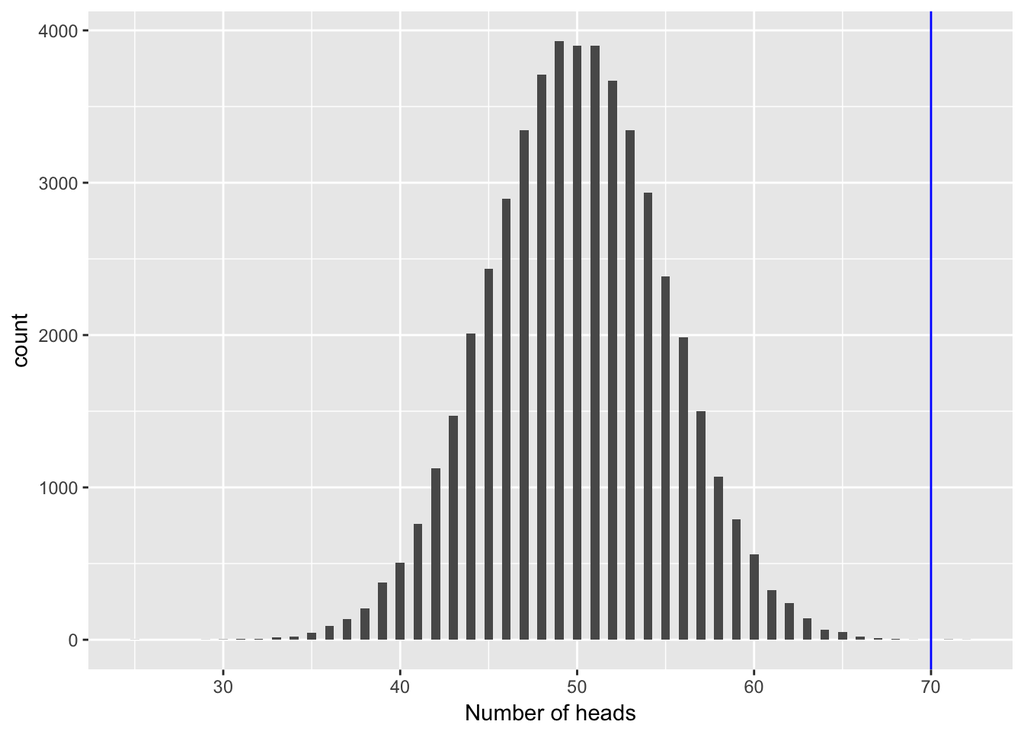

```r
# set the random seed so that the sample is identical each time
set.seed(1234567899)

nSamples=50000
sampleData=rbinom(nSamples,100,0.5)

ggplot(data.frame(sampleData=sampleData),aes(sampleData)) +
  geom_histogram(bins=100,binwidth=0.5,center=0) +
  geom_vline(aes(xintercept=70),color='blue') +
  xlab('Number of heads')
```

```r
print(paste('Number of random samples >= 70 heads):',sum(sampleData>=70)))
```

```
## [1] "Number of random samples >= 70 heads): 3"
```

```r
print(paste('Proportion of random samples >= 70 heads):',mean(sampleData>=70)))
```

```
## [1] "Proportion of random samples >= 70 heads): 6e-05"
```

```r
print(paste('Binomial distribution: p(X>=70|p=0.5):',1-pbinom(69,100,0.5)))
```

```
## [1] "Binomial distribution: p(X>=70|p=0.5): 3.92506982279661e-05"
```

Let’s test a question about the NHANES dataset, using a sample of 250 individuals: Is regular physical activity related to body mass index?

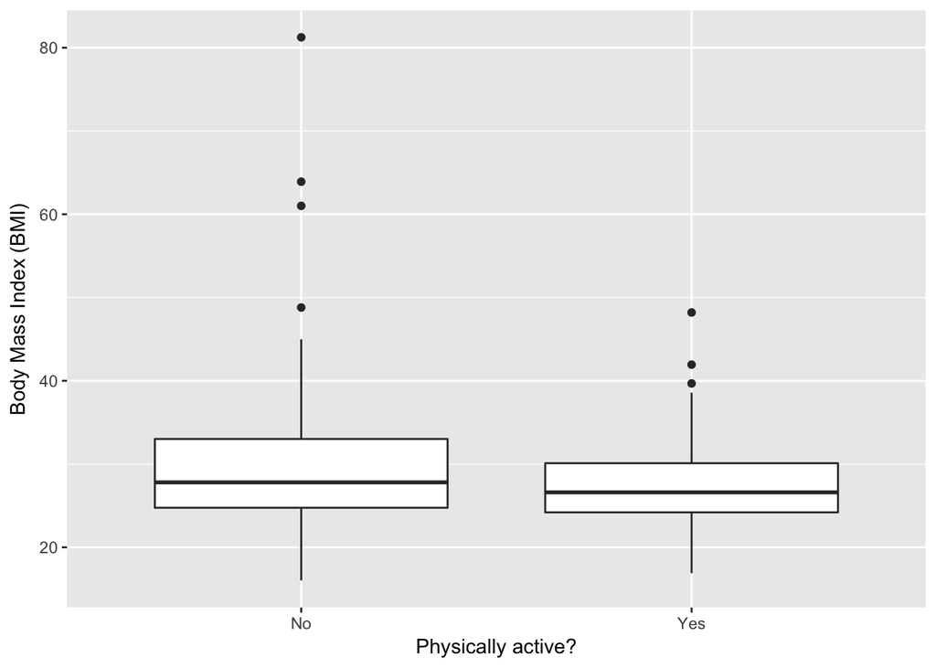

```r
# set the random seed so that the sample is identical each time
set.seed(1234567899)


NHANES$isChild <- NHANES$Age<18
NHANES_adult=subset(NHANES,subset=!isChild & BMI!='NA' & PhysActive!='NA' )

# take a sample from the NHANES dataset
sampSize=250
NHANES_sample=sample_n(NHANES_adult,sampSize)

ggplot(NHANES_sample,aes(PhysActive,BMI)) +
  geom_boxplot() + xlab('Physically active?') + ylab('Body Mass Index (BMI)')
```

```r
sampleSummary=group_by(NHANES_sample,PhysActive) %>% summarize(N=length(BMI),mean=mean(BMI),sd=sd(BMI))

print(sampleSummary)
```

```
## # A tibble: 2 x 4
##   PhysActive     N  mean    sd
##   <fct>      <int> <dbl> <dbl>
## 1 No           125  29.6  8.83
## 2 Yes          125  27.4  5.07
```

```r
meanDiff=sampleSummary[1,3] - sampleSummary[2,3]
```

Let’s perform permutation to assess the distribution of proportions under the null hypothesis of no relations. This is a fairly large dataset so this analysis could take a couple of minutes to complete.

```r
nSamples=2500

bmiData=subset(NHANES_adult,select=c(BMI,PhysActive))

bmiDataShuffled=bmiData

meanDiffSim=array(NA,nSamples)
for (i in 1:nSamples){
  #shuffle the labels
  bmiDataShuffled$PhysActive=sample(bmiDataShuffled$PhysActive)
  # compute the difference
  simResult=t.test(bmiDataShuffled$BMI[bmiDataShuffled$PhysActive=='No'],bmiDataShuffled$BMI[bmiDataShuffled$PhysActive=='Yes'],var.equal=TRUE)
  meanDiffSim[i]=simResult$statistic
}

meanDiffSimDf=data.frame(meanDiffSim=meanDiffSim)
```

Let’s compare the histogram of differences under the null hypothesis to the observed difference between the groups.

```r
print(meanDiff)
```

```
##      mean
## 1 2.22616
```

```r
print(paste('maximum observed different in permutation sample:',max(meanDiffSimDf$meanDiffSim)))
```

```
## [1] "maximum observed different in permutation sample: 3.30863936040246"
```

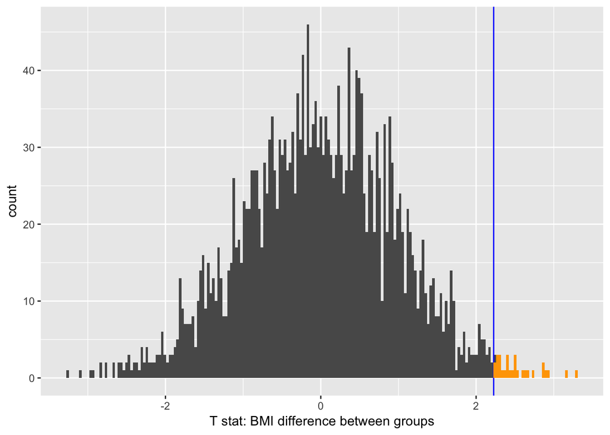

```r
ggplot(meanDiffSimDf,aes(meanDiffSim)) +
  geom_histogram(bins=200) +
  geom_vline(aes(xintercept=meanDiff),color='blue') +
  xlab('T stat: BMI difference between groups') +
  geom_histogram(data=subset(meanDiffSimDf,subset=meanDiffSim>=meanDiff[1,1]),aes(meanDiffSim),bins=200,fill='orange')
```

Instead of using an empirical null distribution, it’s common to use a theoretical null distribution. For differences between means, the appropriate distribution is the Student’s t distribution, with a number of degrees of freedom determined by the sample size; for two groups, since we are estimating the mean for each group, df = N - 2

Let’s plot the t distribution over the empirical null distribution.

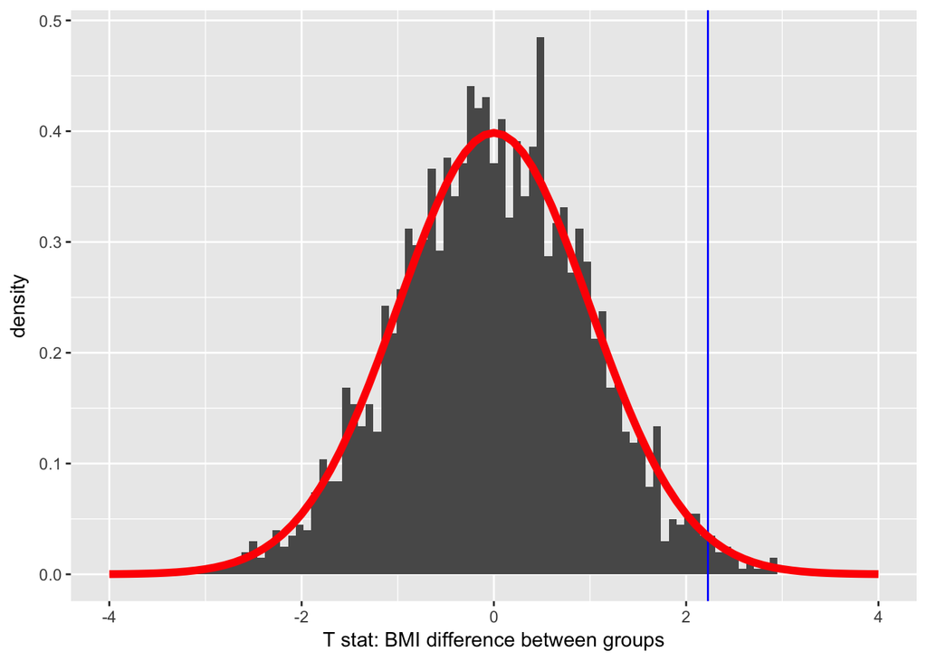

```r
x=seq(-4,4,0.1)
tdist=dt(x,sampSize)

ggplot(meanDiffSimDf,aes(meanDiffSim)) +
  geom_histogram(aes(y=..density..),bins=100) +
  geom_vline(aes(xintercept=meanDiff),color='blue') +
  xlab('T stat: BMI difference between groups') + xlim(-4,4) +
  geom_line(data=data.frame(tdist=tdist,x=x),aes(x,tdist),color='red',size=2)
```

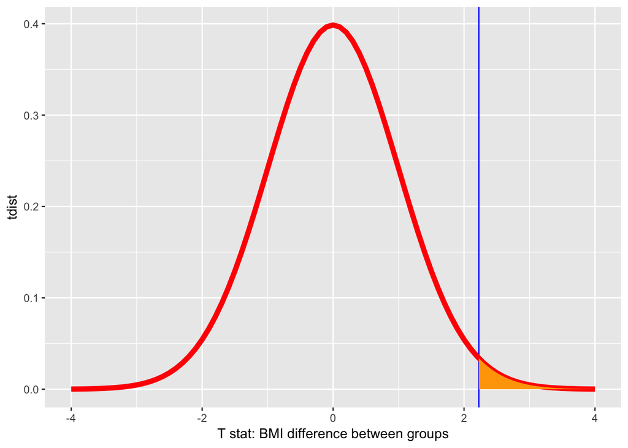

```r
dtfun=function(x){
  return(dt(x,248))
}
ggplot(meanDiffSimDf,aes(meanDiffSim)) +
  geom_vline(aes(xintercept=meanDiff),color='blue') +
  xlab('T stat: BMI difference between groups') + xlim(-4,4) +
  geom_line(data=data.frame(tdist=tdist,x=x),aes(x,tdist),color='red',size=2) +
  stat_function(fun = dtfun,
                xlim = c(meanDiff[1,1],4),
                geom = "area",fill='orange')
```

We can also plot the cumulative distributions against one another.

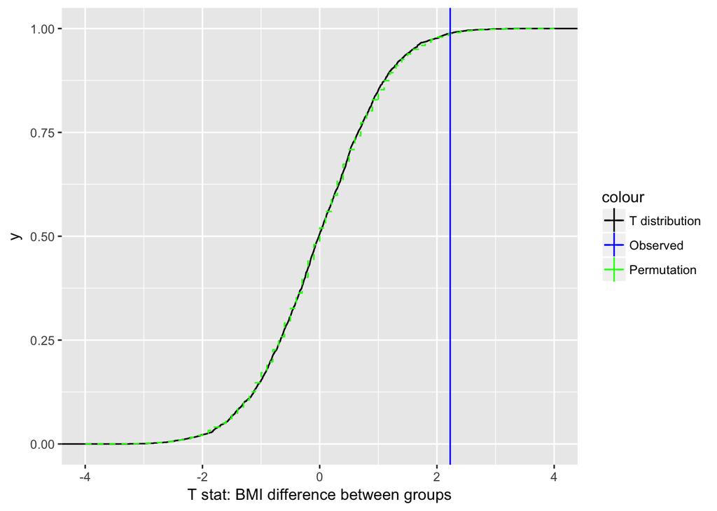

```r
ggplot(meanDiffSimDf,aes(meanDiffSim)) +
  stat_ecdf(aes(color='black')) +
  geom_step(data=data.frame(tdist=cumsum(tdist)/sum(tdist),x=x),
            aes(x,tdist,color='green'),linetype='dashed') +
  xlab('T stat: BMI difference between groups') + xlim(-4,4) +
  geom_vline(aes(xintercept=meanDiff,color='blue')) +
  scale_color_manual(values=c('black','blue','green'),labels = c("T distribution", "Observed","Permutation"))
```

We can compute the likelihood of the observed result under the null hypothesis, first using the theoretical t distribution. To do this, we need to determine the probability of finding a value as large or larger than the observed value under this distribution. To do this, we can use the pt() function which determines the cumulative probability of a particular value of the t distribution given a certain number of degrees of freedom. In this case, we use df=248 since there are 250 observations and we are estimating two parameters (the means of each group).

We will just keep it easy and compute the t statistic using the built in t.test() function.

```r
ttestResult = t.test(BMI~PhysActive,data=NHANES_sample,var.equal=TRUE,alternative='greater')
print(ttestResult)
```

```
##
##  Two Sample t-test
##
## data:  BMI by PhysActive
## t = 2.4452, df = 248, p-value = 0.007587
## alternative hypothesis: true difference in means is greater than 0
## 95 percent confidence interval:
##  0.7230215       Inf
## sample estimates:
##  mean in group No mean in group Yes
##          29.63752          27.41136
```

```r
lowerpt=pt(ttestResult$statistic,sampSize-2)
print(paste('lower tail probability (t distribution):',lowerpt[1]))
```

```
## [1] "lower tail probability (t distribution): 0.992412660001234"
```

Since the total probability sums to 1, the probabilty of a value larger than our observed value is simply one minus the lower tail probability:

```r
upperpt=1 - lowerpt
print(paste('upper tail probability (t distribution):',upperpt[1]))
```

```
## [1] "upper tail probability (t distribution): 0.00758733999876637"
```

Let’s compare that to the probability of finding a value as large as or larger than the observed value in the distribution of permutation results.

```r
print(paste('Number of',nSamples,'permutations equal to or greater than t =',
            ttestResult$statistic,':',
            sum(meanDiffSim>=ttestResult$statistic )))
```

```
## [1] "Number of 2500 permutations equal to or greater than t = 2.44517514958295 : 16"
```

```r
upperpPerm=mean(meanDiffSim>=ttestResult$statistic )
print(paste('upper tail probability (permutation distribution):',upperpPerm[1]))
```

```
## [1] "upper tail probability (permutation distribution): 0.0064"
```

What happens if we rerun the test as a two-tailed (non-directional) test?

```r
ttestResult = t.test(BMI~PhysActive,data=NHANES_sample,var.equal=TRUE,alternative='two.sided')
print(ttestResult)
```

```
##
##  Two Sample t-test
##
## data:  BMI by PhysActive
## t = 2.4452, df = 248, p-value = 0.01517
## alternative hypothesis: true difference in means is not equal to 0
## 95 percent confidence interval:
##  0.4329999 4.0193201
## sample estimates:
##  mean in group No mean in group Yes
##          29.63752          27.41136
```

#### Neyman-Pearson

Let’s simulate a situation in order to see how the different aspects of the Neyman-Pearson approach work together.

Let’s simulate performance from two groups of subjects (say, Californians and Texans) on a test of marijuana sensitivity, which has a mean of 10 and a standard deviation of 1. We will start by simulating a dataset where the is no true difference.

Because we will want to reuse this simulation, let’s first create a function that performs the simulation.

```r
runSimulation=function(trueDifference,nPerGroup,alpha=0.05,nSims=5000,
                       print.output=FALSE){
  pVals=array(NA,nSims)
  for (i in 1:nSims){
    simData_CA=rnorm(nPerGroup,mean=10,sd=1)
    simData_TX=rnorm(nPerGroup,mean=10+trueDifference,sd=1)
    t.result=t.test(simData_CA,simData_TX,var.equal=TRUE)
    pVals[i]=t.result$p.value
  }
  if (print.output){
    print(paste('proportion of significant results (over',
              nSims,'simulations):',mean(pVals<=alpha)))
  }
  return(mean(pVals<=alpha))
}

nPerGroup=20
trueDifference=0
sim.out=runSimulation(trueDifference,nPerGroup,print.output=TRUE)
```

```
## [1] "proportion of significant results (over 5000 simulations): 0.0516"
```

You can see that over many simulations, the probability of finding a significant result (which is a false positive, since there is no true difference) is very close to alpha.

Now let’s see what happens when there truly is a difference between the groups. First let’s assume that it’s a really large difference.

```r
nPerGroup=20
trueDifference=1
sim.out=runSimulation(trueDifference,nPerGroup,print.output=TRUE)
```

```
## [1] "proportion of significant results (over 5000 simulations): 0.869"
```

When the effect is large (in this case it’s 1 standard deviation, which is a pretty large effect) then we will reject the null hypothesis most of the time - but not all of the time.

Let’s see how the likelihood of finding a significant result changes as a function of the size of the effect.

```r
trueDifferences=seq(0,2,0.1)
proportionSignificant=array(NA,length(trueDifferences))
for (i in 1:length(trueDifferences)){
  proportionSignificant[i]=runSimulation(trueDifferences[i],nPerGroup)
}
```

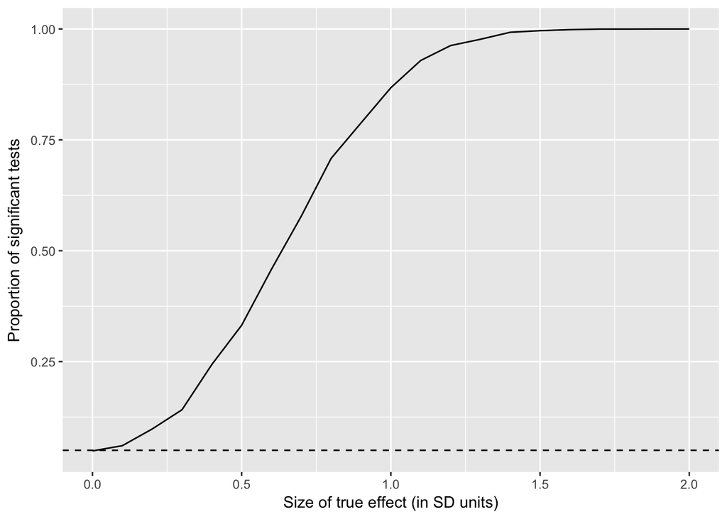

```r
ggplot(data.frame(trueDiff=trueDifferences,propSig=proportionSignificant),
       aes(trueDiff,propSig)) +
  geom_line() +
  xlab('Size of true effect (in SD units)') + ylab('Proportion of significant tests') +
  geom_hline(yintercept = 0.05,linetype='dashed')
```

What do you think happens if we increase the sample size? Let’s try it with several different sample sizes to see what effect that has. This could take a couple of minutes to complete.

```r
trueDifferences=seq(0,2,0.2)
sampleSizes=c(20,40,60,80)
proportionSignificant=array(NA,length(sampleSizes)*length(trueDifferences))
sampleSize=array(NA,length(sampleSizes)*length(trueDifferences))
trueDifference=array(NA,length(sampleSizes)*length(trueDifferences))
i=1
for (td in trueDifferences){
  for (ss in sampleSizes) {
    sampleSize[i]=ss
    trueDifference[i]=td
    proportionSignificant[i]=runSimulation(td,ss)
    i=i+1
  }
}
```

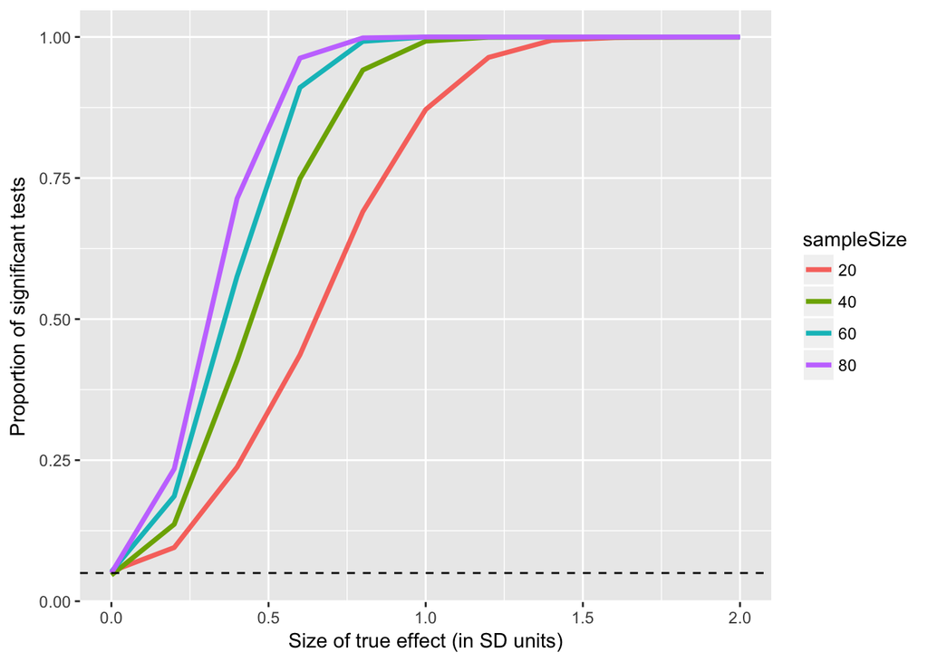

```r
df=data.frame(trueDiff=trueDifference,propSig=proportionSignificant,sampleSize=as.factor(sampleSize))
ggplot(df,aes(trueDiff,propSig,color=sampleSize)) +
  geom_line(size=1.25) +
  xlab('Size of true effect (in SD units)') + ylab('Proportion of significant tests') +
  geom_hline(yintercept = 0.05,linetype='dashed')
```

```r
trueDifferences=seq(0,2,0.2)
sampleSize=40
alphas=c(0.001,0.005,0.01,0.05,0.1)
proportionSignificant=array(NA,length(alphas)*length(trueDifferences))
alpha=array(NA,length(alphas)*length(trueDifferences))
trueDifference=array(NA,length(alphas)*length(trueDifferences))
i=1
for (td in trueDifferences){
  for (a in alphas) {
    alpha[i]=a
    trueDifference[i]=td
    proportionSignificant[i]=runSimulation(td,ss,alpha=a)
    i=i+1
  }
}
```

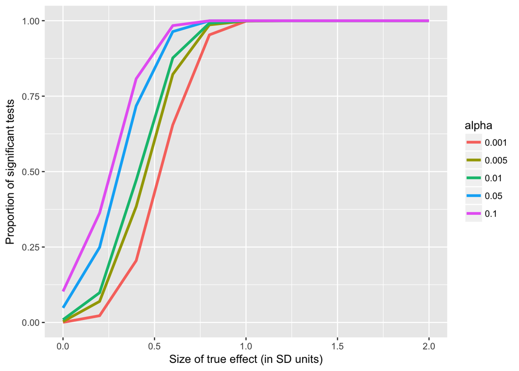

```r
df=data.frame(trueDiff=trueDifference,propSig=proportionSignificant,alpha=as.factor(alpha))
ggplot(df,aes(trueDiff,propSig,color=alpha)) +
  geom_line(size=1.25) +
  xlab('Size of true effect (in SD units)') + ylab('Proportion of significant tests')
```

Let’s see what happens with a really small effect as the sample size gets large. This could take a few minutes.

```r
sampleSizes=2**seq(4,18)
proportionSignificant=array(NA,length(sampleSizes))
for (i in 1:length(sampleSizes)){
  proportionSignificant[i]=runSimulation(0.01,sampleSizes[i])
}
```

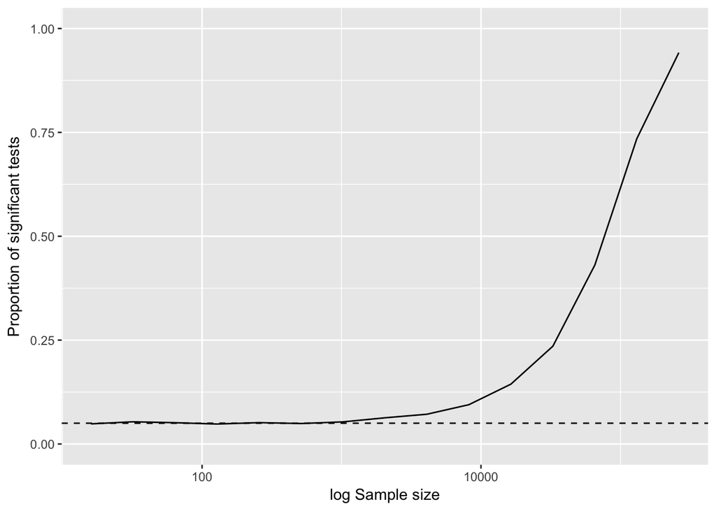

```r
df=data.frame(sampleSize=sampleSizes,propSig=proportionSignificant)
ggplot(df,
       aes(sampleSize,propSig)) +
  geom_line() + ylim(0,1) + scale_x_log10() +
  xlab('log Sample size') + ylab('Proportion of significant tests') +
  geom_hline(yintercept = 0.05,linetype='dashed')
```

```r
print(df)
```

```
##    sampleSize propSig
## 1          16  0.0484
## 2          32  0.0534
## 3          64  0.0512
## 4         128  0.0480
## 5         256  0.0514
## 6         512  0.0492
## 7        1024  0.0532
## 8        2048  0.0630
## 9        4096  0.0716
## 10       8192  0.0946
## 11      16384  0.1440
## 12      32768  0.2354
## 13      65536  0.4308
## 14     131072  0.7350
## 15     262144  0.9420
```

### Positive predictive value

The positive predictive value is the proportion of positive outcomes (i.e. rejection of the null) that are correct. This moves with three things: - alpha (false positive rate) - power (1 - false negative rate) - prior probability that the hypothesis is correct

Let’s plot an example

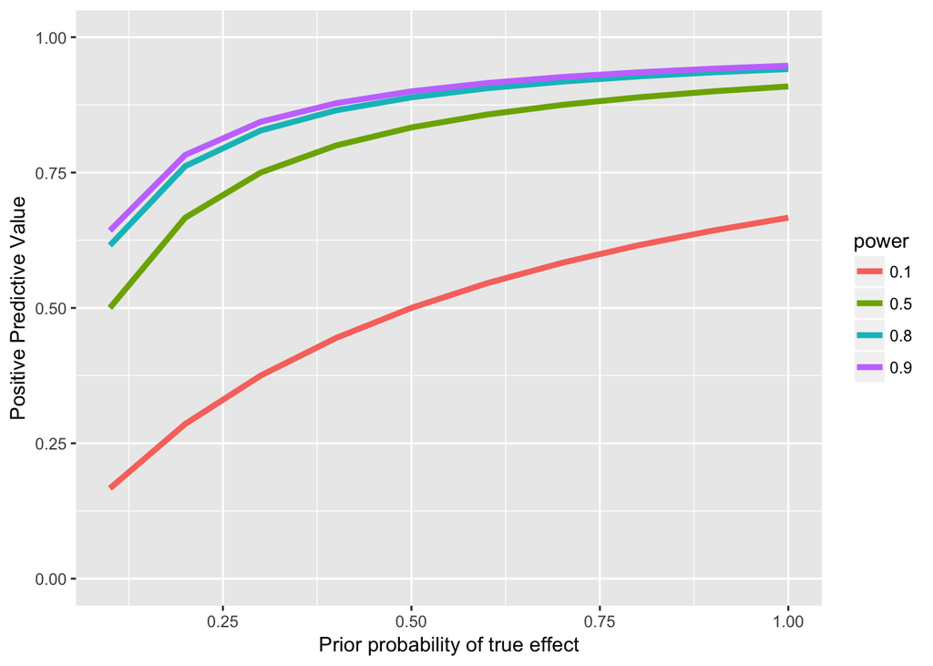

```r
ppv = function(alpha,power,prior){
  return ((power*prior)/(power*prior + alpha))
}
powerVals=c(0.1,0.5,0.8,0.9)
priorVals=seq(0.1,1,0.1)
ppvVal=array(NA,length(powerVals)*length(priorVals))
i=1
powerVal=array(NA,length(powerVals)*length(priorVals))
priorVal=array(NA,length(powerVals)*length(priorVals))

for (pwr in powerVals){
  for (prior in priorVals){
    ppvVal[i]=ppv(0.05,pwr,prior)
    powerVal[i]=pwr
    priorVal[i]=prior
    i=i+1
  }
}

df=data.frame(ppv=ppvVal,fdr=1-ppvVal,prior=priorVal,power=as.factor(powerVal))

ggplot(df,aes(priorVal,ppv,color=power)) +
  geom_line(size=1.5) + ylab('Positive Predictive Value') +
  xlab('Prior probability of true effect') + ylim(0,1)
```

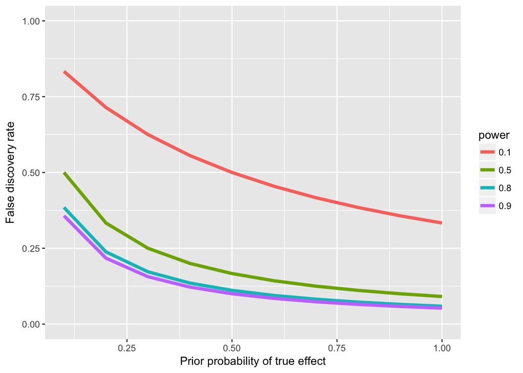

```r
ggplot(df,aes(priorVal,fdr,color=power)) +
  geom_line(size=1.5) + ylab('False discovery rate') +
  xlab('Prior probability of true effect') + ylim(0,1)
```

### Schizophrenia example

```r
oddsRatioChr6=1.167
pSZ=7.2/1000
pGene=1 - 0.763

# we just assume here that the unexposed rates are the population prevalence

oddsNoGene=pSZ/(1-pSZ)
1/oddsNoGene
```

```
## [1] 137.8889
```

```r
oddsGene = oddsRatioChr6*oddsNoGene
1/oddsGene
```

```
## [1] 118.1567
```

```r
# this one is for rs171748
oddsRatioChr6=1.08
pSZ=7.2/1000
pGene=1 -  0.471

# we just assume here that the unexposed rates are the population prevalence

oddsNoGene=pSZ/(1-pSZ)
1/oddsNoGene
```

```
## [1] 137.8889
```

```r
oddsGene = oddsRatioChr6*oddsNoGene
1/oddsGene
```

```
## [1] 127.6749
```

### simulating multiple testing

```r
nTests=10000
uncAlpha=0.05
uncOutcome=replicate(nTests,sum(rnorm(nTests)<(qnorm(uncAlpha))))

print(paste('uncorrected:',mean(uncOutcome>0)))
```

```
## [1] "uncorrected: 1"
```

```r
corAlpha=0.05/nTests

corOutcome=replicate(nTests,sum(rnorm(nTests)<(qnorm(corAlpha))))
print(paste('corrected:',mean(corOutcome>0)))
```

```
## [1] "corrected: 0.0487"
```

### Randomization example

```r
roundToNearest5 <- function(x,base=5){
        return(base*round(x/base))
}

set.seed(123456)
df=data.frame(group=as.factor(c(rep('FB',5),rep('XC',5))),
              squat=roundToNearest5(c(rnorm(5)*30 + 300,rnorm(5)*30 + 140)))


df = df %>% mutate(scrambledGroup=sample(group))
df = df %>% mutate(scrambledGroup2=sample(group))
df
```

| group | squat | scrambledGroup | scrambledGroup2 |
| --- | --- | --- | --- |
| FB | 325 | FB | XC |
| FB | 290 | FB | XC |
| FB | 290 | XC | FB |
| FB | 305 | XC | FB |
| FB | 370 | FB | FB |
| XC | 165 | FB | XC |
| XC | 180 | FB | FB |
| XC | 215 | XC | FB |
| XC | 175 | XC | XC |
| XC | 125 | XC | XC |

```r
tt=t.test(squat~group,data=df,var.equal=TRUE)
tt
```

```
##
##  Two Sample t-test
##
## data:  squat by group
## t = 6.9242, df = 8, p-value = 0.0001215
## alternative hypothesis: true difference in means is not equal to 0
## 95 percent confidence interval:
##   96.04288 191.95712
## sample estimates:
## mean in group FB mean in group XC
##              316              172
```

```r
tt_scram=t.test(squat~scrambledGroup,data=df,var.equal=TRUE)
tt_scram
```

```
##
##  Two Sample t-test
##
## data:  squat by scrambledGroup
## t = 0.83413, df = 8, p-value = 0.4284
## alternative hypothesis: true difference in means is not equal to 0
## 95 percent confidence interval:
##  -77.64035 165.64035
## sample estimates:
## mean in group FB mean in group XC
##              266              222
```

```r
tt_scram2=t.test(squat~scrambledGroup2,data=df,var.equal=TRUE)
tt_scram2
```

```
##
##  Two Sample t-test
##
## data:  squat by scrambledGroup2
## t = 1.0914, df = 8, p-value = 0.3069
## alternative hypothesis: true difference in means is not equal to 0
## 95 percent confidence interval:
##  -62.31622 174.31622
## sample estimates:
## mean in group FB mean in group XC
##              272              216
```

Now randomize order 10000 times to get histogram

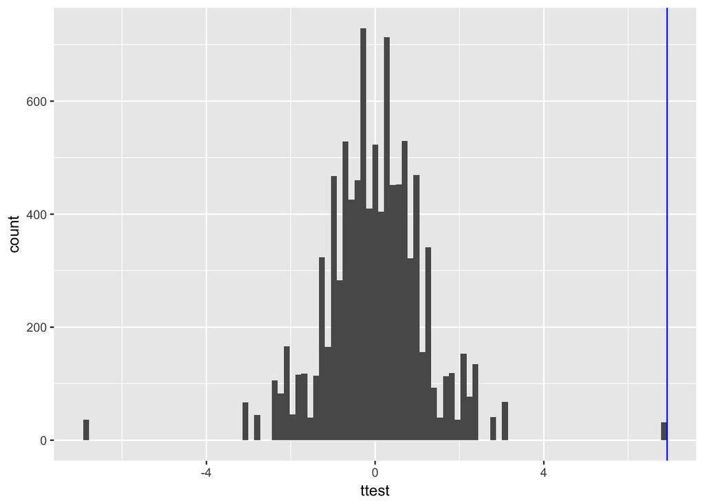

```r
getScrambledTtest = function(dfScram){
  dfScram$group = sample(dfScram$group)
  tt=t.test(squat~group,data=dfScram,var.equal=TRUE)
  return(tt$statistic)
}

ttestScrambledResults = replicate(10000,getScrambledTtest(df))

ggplot(data.frame(ttest=ttestScrambledResults),aes(ttest)) +
  geom_histogram(bins=100) +
  geom_vline(xintercept = tt$statistic,color='blue')
```

```r
mean(ttestScrambledResults)
```

```
## [1] -0.001208376
```

```r
max(ttestScrambledResults)
```

```
## [1] 6.924197
```

```r
mean(ttestScrambledResults>=tt$statistic)
```

```
## [1] 0.0032
```